# Practical Forecast

## Practice RTMB

- Start with 1 stock and see if you can forecast
- Include age as part of the model
- One option is to have a different Ricker curve for each age class
- Add covariates
- Run a retrospective analysis: forecast each of the last 22 returns from the data available at the time
- Compare your forecasts with a simple benchmark

## Load in Data

- Example Stellako

```r
library(ggplot2)
library(dplyr)
library(tidyr)
library(RTMB)

# Paths start at the project root via here::here(), so this code runs in the
# Positron or RStudio console and when Quarto renders from this folder.
sox <- read.csv(here::here("data", "sockeye", "SRDATA2026 1.csv"))
stock <- read.csv(here::here("data", "sockeye", "FC_StockInfo 2.csv"))
## This file starts with a byte-order mark. Without fileEncoding, R on some
## systems reads the first column name as "X...yr" and the join below fails.
covariates <- read.csv(here::here("data", "sockeye", "FC_Environmental_Data_2026_Std_Offset_Real.csv"),
                       fileEncoding = "UTF-8-BOM")
sox <- sox %>% left_join(stock, by = "PopID")
sox <- sox %>% left_join(covariates, by = "yr")
sox <- sox %>% filter(!is.na(spawners), !is.na(recruits))
sox <- sox %>% group_by(PopName) %>% mutate(sd_spawners = sd(spawners),  spawners_scaled = spawners/sd_spawners) %>% ungroup()
```

## Age Based Ricker Model

- Density dependence ($\beta$) is shared between ages, productivity is not.
- The observations are related so will choose,

$$\log(R_{at}/S_t) \sim N(\boldsymbol{\alpha}_a - \beta S_t, \Sigma)$$

- Given that we have age 4 returns with `NA` for age 5, we can write this as a conditional normal, for $y_{at} = \log(R_{at}/S_t)$,

$$\begin{align}
y_{4t} & \sim N(\mu_{4t}, \Sigma_{11})\\
y_{5t} | y_{4t} & \sim N(\mu_{5t} + \Sigma_{12}/\Sigma_{11}(y_{4t} - \mu_{4t}), \Sigma_{22} - \Sigma_{12}^2/\Sigma_{11})
\end{align}$$

## Fitting it in RTMB

```r
negll <- function(pars, data){
  getAll(pars, data, warn = FALSE)

  phi <- -1 + 2*plogis(logitphi)
  sigma <- exp(logsigma)
  beta <- exp(logbeta)
  mis4 <- is.na(logRS4)
  mis5 <- is.na(logRS5)

  ## Sigma11 = sigma[1]^2, Sigma22 = sigma[2]^2, Sigma12 = phi*sigma[1]*sigma[2]
  mu4 <- alpha[1] - beta*spawners
  ## Age 5 given age 4 from the same brood year (a "sibling" relationship).
  ## Where age 4 is missing there is nothing to condition on: age 5 on its own.
  dev4 <- logRS4 - mu4
  dev4[mis4] <- 0
  mu5 <- alpha[2] - beta*spawners + phi*sigma[2]/sigma[1]*dev4
  sigma5 <- sigma[2]*sqrt(1 - phi^2*(!mis4))

  ll <- sum(dnorm(logRS4[!mis4], mu4[!mis4], sigma[1], log = TRUE))
  ll <- ll + sum(dnorm(logRS5[!mis5], mu5[!mis5], sigma5[!mis5], log = TRUE))

  ## Prediction is last year of 4 plus previous year of 5.
  ## exp() of a mean on the log scale is a median, not a mean.
  n <- length(mu4)
  med4 <- exp(mu4)*spawners
  med5 <- exp(mu5)*spawners
  pred <- med4[n] + med5[n-1]
  REPORT(pred)
  REPORT(med4)
  REPORT(med5)

  ## The same two pieces on the log scale, with their standard deviations.
  ## Used for the mean, and later for a forecast interval.
  fc <- c(log(med4[n]), log(med5[n-1]))
  sd_fc <- c(sigma[1], sigma5[n-1])
  pred_mean <- sum(exp(fc + sd_fc^2/2))
  ADREPORT(fc)
  REPORT(sd_fc)
  REPORT(pred_mean)
  return(-ll)
}
```

## Zero Returns

- A zero return has no logarithm.
- Adding a small constant before taking the log is arbitrary, and the estimates depend on which constant you pick.
- Here a zero is treated as missing. That is reasonable when zeros are rare (Stellako has one).
- With many zeros, model total recruits and the split between ages separately.

```r
sox_ch <- sox %>% filter(PopName == "Stellako") %>%
  mutate(logRS4 = ifelse(age4 > 0, log(age4/spawners), NA),
    logRS5 = ifelse(age5 > 0, log(age5/spawners), NA))
```

## Prediction

- Prediction: Combine age 4 prediction with spawners 4 years ago with age 5 expected from the previous spawner group.

```r
cmb <- function(f, d, ...) function(p) f(p, d, ...)

params <- list(
  logsigma = c(0,0),
  alpha = c(0,0),
  logbeta = 0,
  logitphi = 0
  )

obj <- MakeADFun(cmb(negll, sox_ch), params, silent = TRUE)
fit <- nlminb(obj$par, obj$fn, obj$gr, control = list(eval.max = 1e4, iter.max = 1e4))
fit$message
```

```
[1] "relative convergence (4)"
```

## Median or Mean?

- `exp()` of a mean on the log scale is the **median** of a lognormal. Its mean is larger by $e^{\sigma^2/2}$.

```r
## Report at the best parameters found (not the last ones the optimizer tried)
rep <- obj$report(obj$env$last.par.best)
round(c(sum_of_medians = rep$pred, sum_of_means = rep$pred_mean), 3)
```

```
sum_of_medians   sum_of_means
         0.359          0.558
```

- The two are far apart when $\sigma$ is near 1, as it is here. Say which one you forecast.

## How Uncertain is the Forecast?

- An interval needs the uncertainty in the estimates and the year to year variation in recruitment. Simulate both.

```r
forecast_dist <- function(obj, nsim = 4000){
  rep <- obj$report(obj$env$last.par.best)
  sdr <- sdreport(obj)
  ## 1. Uncertainty in the estimates: draw the two log-scale means we passed to ADREPORT
  m <- MASS::mvrnorm(nsim, sdr$value, sdr$cov)
  ## 2. Variation in recruitment around those means (sigma)
  total <- exp(rnorm(nsim, m[,1], rep$sd_fc[1])) + exp(rnorm(nsim, m[,2], rep$sd_fc[2]))
  q <- quantile(total, c(0.1, 0.5, 0.9))
  c(pred = rep$pred, lower = q[[1]], median = q[[2]], upper = q[[3]])
}

set.seed(2026)
round(forecast_dist(obj), 3)   ## 80% interval for the last return in the data
```

```
  pred  lower median  upper
 0.359  0.123  0.366  1.190
```

## Do Prediction

```r
## Refit each year with only the data available at the time, and forecast the next return
hindcast <- function(make_obj, years = 2000:2021){
  out <- NULL
  for( i in seq_along(years) ){
    dat <- sox_ch %>% filter(yr <= years[i])
    ## Hide the returns that would not be known yet
    dat$logRS4[dat$yr == years[i]] <- NA
    dat$logRS5[dat$yr == years[i]] <- NA
    dat$logRS5[dat$yr == years[i]-1] <- NA
    obj <- make_obj(dat)
    fit <- nlminb(obj$par, obj$fn, obj$gr, control = list(eval.max = 1e4, iter.max = 1e4))
    out <- rbind(out, c(forecast_dist(obj), convergence = fit$convergence))
  }
  data.frame(year = years + 4, out, row.names = NULL)
}

set.seed(2026)
pred <- hindcast(function(dat) MakeADFun(cmb(negll, dat), params, silent = TRUE))
sum(pred$convergence != 0)   ## refits that did not converge
```

```
[1] 0
```

## Do Prediction (plot)

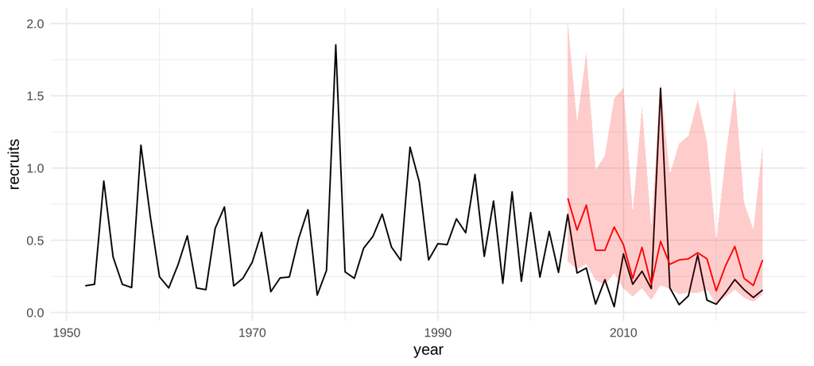

```r
recruits_ch <- sox_ch %>%
  pivot_longer(c(age4, age5)) %>%
  mutate(year = ifelse(name == "age4", yr + 4, yr + 5)) %>%
  group_by(year) %>% summarize(recruits = sum(value))

recruits_ch %>% ggplot(aes(x = year, y = recruits)) + geom_line() + theme_minimal() +
  geom_ribbon(data = pred, aes(x = year, ymin = lower, ymax = upper), inherit.aes = FALSE, fill = 'red', alpha = 0.2) +
  geom_line(data = pred, aes(x = year, y = pred), col = 'red')
```

## How Good is the Forecast?

- Benchmark: the return four years earlier (a “naive” forecast).

```r
skill <- pred %>% left_join(recruits_ch, by = "year") %>%
  left_join(recruits_ch %>% transmute(year = year + 4, naive = recruits), by = "year")
## bias: mean of forecast minus observed. MAE: mean absolute error. In millions of fish.
score <- function(forecast, observed){
  c(bias = mean(forecast - observed), MAE = mean(abs(forecast - observed)),
    too_high = sum(forecast > observed))
}
tab <- rbind(Ricker = score(skill$pred, skill$recruits), Naive = score(skill$naive, skill$recruits))
## MASE: the error relative to the naive forecast. Below 1 beats it.
round(cbind(tab, MASE = tab[, "MAE"]/tab["Naive", "MAE"]), 3)
```

```
        bias   MAE too_high  MASE
Ricker 0.142 0.238       21 1.128
Naive  0.051 0.211       11 1.000
```

- Too high in nearly every year, and no better than naive.

## Do the Intervals Cover?

```r
## Returns inside the 80% interval, out of 22 (expect about 18)
sum(skill$recruits >= skill$lower & skill$recruits <= skill$upper)
```

```
[1] 14
```

```r
## Returns below the interval (expect about 2)
sum(skill$recruits < skill$lower)
```

```
[1] 8
```

- Too few returns fall inside the 80% interval, and the misses are on the low side.
- An interval that is too narrow, or in the wrong place, is a finding about the model.

## Adding Covariates

- Covariates shift productivity up or down in each brood year.
- Choose few, for reasons you can state in advance, and test them out of sample.

```r
## The same function with two optional additions, marked NEW
negll2 <- function(pars, data, Z = NULL, rw = FALSE){
  getAll(pars, data, warn = FALSE)

  phi <- -1 + 2*plogis(logitphi)
  sigma <- exp(logsigma)
  beta <- exp(logbeta)
  mis4 <- is.na(logRS4)
  mis5 <- is.na(logRS5)

  ## NEW: changes in productivity from year to year
  delta_alpha <- rep(0, length(spawners))
  if(!is.null(Z)) delta_alpha <- delta_alpha + drop(Z %*% a)   ## covariates
  if(rw) delta_alpha <- delta_alpha + a_t[yr - min(yr) + 1]    ## random walk (next model)

  mu4 <- delta_alpha + alpha[1] - beta*spawners
  dev4 <- logRS4 - mu4
  dev4[mis4] <- 0
  mu5 <- delta_alpha + alpha[2] - beta*spawners + phi*sigma[2]/sigma[1]*dev4
  sigma5 <- sigma[2]*sqrt(1 - phi^2*(!mis4))

  ll <- sum(dnorm(logRS4[!mis4], mu4[!mis4], sigma[1], log = TRUE))
  ll <- ll + sum(dnorm(logRS5[!mis5], mu5[!mis5], sigma5[!mis5], log = TRUE))

  ## NEW: random walk (next model)
  if(rw){
    tau <- exp(logtau)
    ll <- ll + dnorm(a_t[1], 0, tau, log = TRUE) + sum(dnorm(diff(a_t), 0, tau, log = TRUE))
  }

  ## Prediction is last year of 4 plus previous year of 5.
  n <- length(mu4)
  med4 <- exp(mu4)*spawners
  med5 <- exp(mu5)*spawners
  pred <- med4[n] + med5[n-1]
  REPORT(pred)
  REPORT(med4)
  REPORT(med5)

  fc <- c(log(med4[n]), log(med5[n-1]))
  sd_fc <- c(sigma[1], sigma5[n-1])
  pred_mean <- sum(exp(fc + sd_fc^2/2))
  ADREPORT(fc)
  REPORT(sd_fc)
  REPORT(pred_mean)
  return(-ll)
}
```

## Fitting with Covariates

- No intercept column in `Z`: `alpha` already is one, and two intercepts cannot be told apart.
- Center and scale: effects are then per standard deviation, and the optimizer has an easier job.

```r
covs <- c("peak", "aflow", "jnesst", "pdo", "stn2js")
Z <- scale(as.matrix(sox_ch[, covs]))

params_cov <- c(params, list(a = rep(0, ncol(Z))))

obj_cov <- MakeADFun(cmb(negll2, sox_ch, Z), params_cov, silent = TRUE)
fit_cov <- nlminb(obj_cov$par, obj_cov$fn, obj_cov$gr, control = list(eval.max = 1e4, iter.max = 1e4))
fit_cov$message
```

```
[1] "relative convergence (4)"
```

## Do the Covariates Help?

```r
est <- summary(sdreport(obj_cov), "fixed")
est <- est[rownames(est) == "a", ]
rownames(est) <- covs
round(cbind(est, z = est[, "Estimate"]/est[, "Std. Error"]), 2)
```

```
       Estimate Std. Error     z
peak       0.01       0.11  0.11
aflow      0.00       0.11  0.03
jnesst    -0.24       0.11 -2.24
pdo        0.01       0.11  0.05
stn2js     0.20       0.11  1.74
```

```r
aic <- function(fit) 2*fit$objective + 2*length(fit$par)
round(c(Ricker = aic(fit), Covariates = aic(fit_cov)), 1)
```

```
    Ricker Covariates
     400.5      402.6
```

- One effect of five is more than two standard errors from zero, and AIC is lower without them.

## Productivity that Changes over Time

- The forecasts are too high because productivity has declined. One $\alpha$ for 74 years averages over that.
- Let productivity drift as a random walk. For brood year $t$,

$$\alpha_{at} = \alpha_a + u_t, \qquad u_t \sim N(u_{t-1}, \tau^2)$$

- $u_t$ is a random effect (`a_t` in the code), so this is one more job for the Laplace approximation.
- A random walk predicts “the same as the latest value”, so the forecast uses recent productivity.

## Fitting the Random Walk

```r
make_rw <- function(dat){
  params_rw <- c(params, list(a_t = rep(0, max(dat$yr) - min(dat$yr) + 1), logtau = log(0.2)))
  MakeADFun(cmb(negll2, dat, rw = TRUE), params_rw, random = "a_t", silent = TRUE)
}
obj_rw <- make_rw(sox_ch)
fit_rw <- nlminb(obj_rw$par, obj_rw$fn, obj_rw$gr, control = list(eval.max = 1e4, iter.max = 1e4))
fit_rw$message
```

```
[1] "relative convergence (4)"
```

```r
round(c(Ricker = aic(fit), RandomWalk = aic(fit_rw)), 1)
```

```
    Ricker RandomWalk
     400.5      384.4
```

- AIC prefers the random walk. Does it forecast better?

## Productivity over Time (plot)

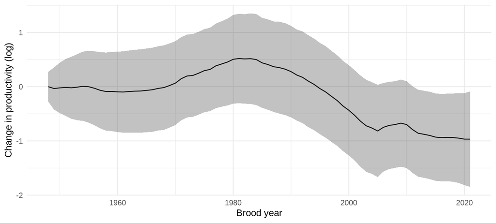

```r
u_hat <- as.data.frame(summary(sdreport(obj_rw), "random"))
names(u_hat) <- c("est", "se")
u_hat$year <- min(sox_ch$yr) + 1:nrow(u_hat) - 1
ggplot(u_hat, aes(x = year, y = est)) + geom_line() + theme_minimal() +
  geom_ribbon(aes(ymin = est - 1.96*se, ymax = est + 1.96*se), alpha = 0.3) +
  xlab("Brood year") + ylab("Change in productivity (log)")
```

## Comparing the Forecasts

```r
set.seed(2026)
pred_cov <- hindcast(function(dat){
  Z <- scale(as.matrix(dat[, covs]))   ## scaled with the data available at the time
  MakeADFun(cmb(negll2, dat, Z), params_cov, silent = TRUE)
})
pred_rw <- hindcast(make_rw)
observed <- skill$recruits
tab <- rbind(Ricker = score(pred$pred, observed), Covariates = score(pred_cov$pred, observed),
             "Random walk" = score(pred_rw$pred, observed), Naive = score(skill$naive, observed))
round(cbind(tab, MASE = tab[, "MAE"]/tab["Naive", "MAE"]), 3)
```

```
              bias   MAE too_high  MASE
Ricker       0.142 0.238       21 1.128
Covariates   0.106 0.216       17 1.023
Random walk -0.012 0.174       12 0.823
Naive        0.051 0.211       11 1.000
```

```r
## Returns inside the 80% interval, out of 22 (expect about 18)
sapply(list(Ricker = pred, Covariates = pred_cov, "Random walk" = pred_rw),
       function(p) sum(observed >= p$lower & observed <= p$upper))
```

```
     Ricker  Covariates Random walk
         14          14          16
```

## Comparing the Forecasts (plot)

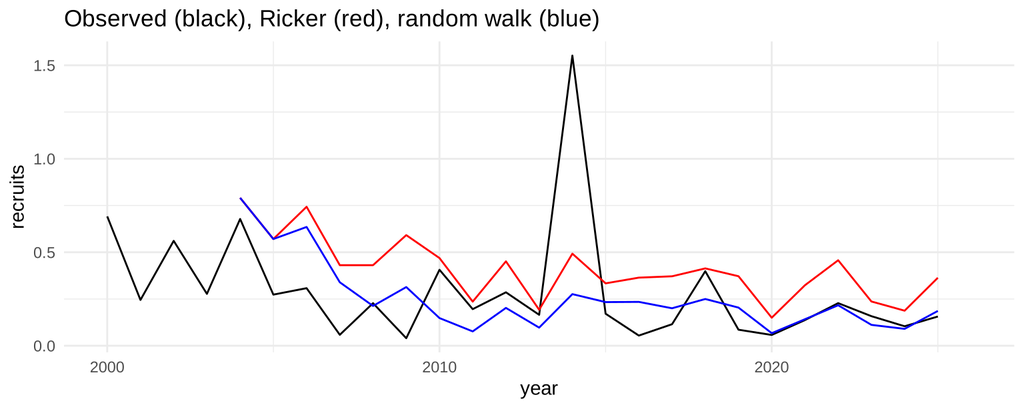

```r
recruits_ch %>% filter(year >= 2000) %>% ggplot(aes(x = year, y = recruits)) + geom_line() + theme_minimal() +
  geom_line(data = pred, aes(x = year, y = pred), col = 'red') +
  geom_line(data = pred_rw, aes(x = year, y = pred), col = 'blue') +
  ggtitle("Observed (black), Ricker (red), random walk (blue)")
```

## What the Hindcast Says

- Stationary Ricker: too high in almost every year.
- Covariates: a small gain, and still no better than the naive forecast.
- Random walk: the bias is gone, and the error is below the naive forecast.
- This is one stock and 22 forecasts. Repeat it for other stocks before you believe it.

## More to Try

- Other stocks. What will you do where many returns are zero (Quesnel)?
- Other benchmarks, such as the mean of all earlier returns.
- Delayed density dependence: the Larkin model.
- Heavier tails for the residuals: do the intervals cover better?
- All stocks at once, sharing information (Module 5).
- Regressing $\log(R/S)$ on $S$ has known biases. State-space models address them: see the `samEst` package.